# Random Walk Test

This is a test if the price of Brent is a random walk. “If a market is weak-form efficient then the change in a security’s price, with respect to the security’s historical price changes, is approximately random because the historical price changes are already reflected in the current price. This is why randomness tests are typically used to test the weak-form efficient market hypothesis.”

Source: http://www.turingfinance.com/testing-the-efficient-market-hypothesis-with-r/

Read in the monthly Brent price

```r
library(ggplot2)
library(Quandl)
library(lmtest)
library(vrtest)
library(quantmod)
# dataFrame <- read.csv("~/EAA_Analytics/Data/BrentPrice.csv")
dataFrame <- read.csv("C:/GitRepos/EAA_Analytics/Data/BrentPrice.csv")
colnames(dataFrame) <- c("date", "BrentPrice")
head(dataFrame)
```

|  | date | BrentPrice |
| --- | --- | --- |
| 1 | 1/1/1990 | 21.25 |
| 2 | 2/1/1990 | 19.93 |
| 3 | 3/1/1990 | 18.37 |
| 4 | 4/1/1990 | 16.49 |
| 5 | 5/1/1990 | 16.34 |
| 6 | 6/1/1990 | 15.05 |

```r
yVar <- dataFrame$BrentPrice
yVarDiff <- diff(yVar, differences = 1)
date <- as.Date(dataFrame$date, format = "%m/%d/%Y")
yVarLag <- Lag(yVar, 1)[,1]
yVarReturn <- (yVar/yVarLag - 1)
```

Read in other commodities and equities from Quandl

```r
goldDf <- Quandl("FRED/GOLDAMGBD228NLBM")
```

Plot the data

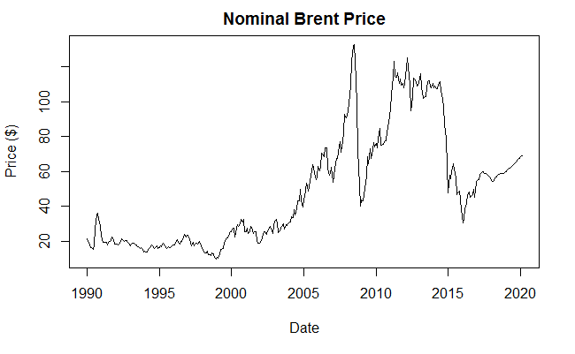

```r
plot(x = date,
     y = yVar,
     type = "l",
     ylab = "Price ($)",
     xlab = "Date",
     main = "Nominal Brent Price")
lines(yVarDiff)
```

ACF: Look for a slow decay in the series Note the persistence and slow decay of the lags in the ACF due to a random walk or a long range dependence.

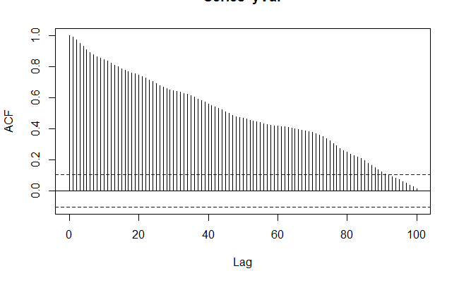

```r
acf(yVar, 100)
```

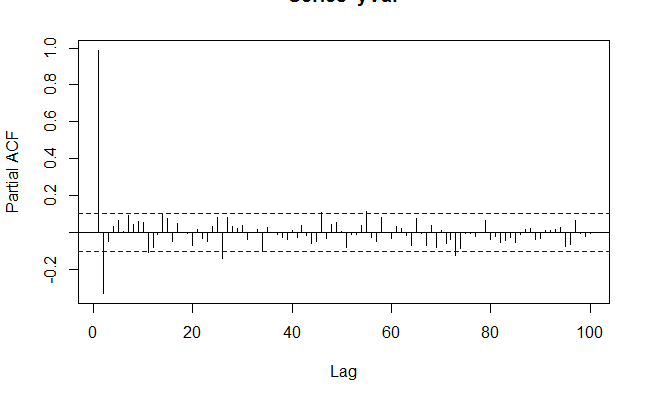

```r
pacf(yVar, 100)
```

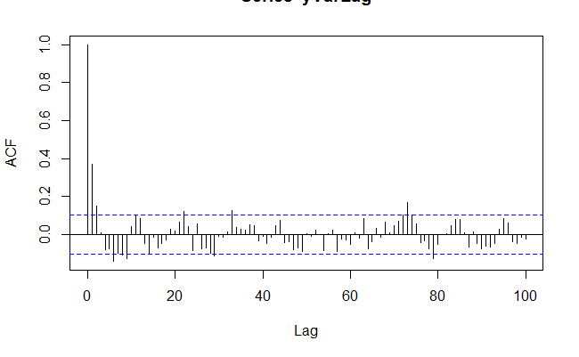

```r
acf(yVarLag, 100)
```

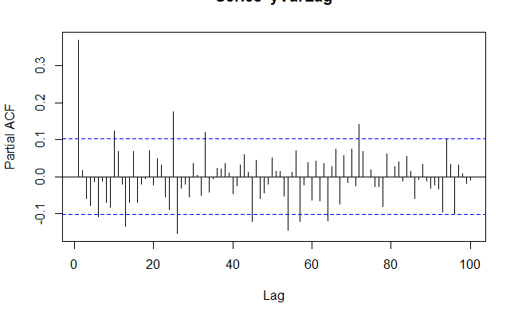

```r
pacf(yVarLag, 100)
```

```r
PP.test(yVarLag)
```

```
    Phillips-Perron Unit Root Test

data:  yVarLag
Dickey-Fuller = -12.735, Truncation lag parameter = 5, p-value = 0.01
```

Cummulative distribution function of the level and returns

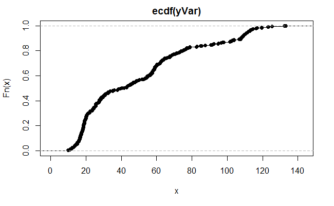

```r
plot(ecdf(yVar))
```

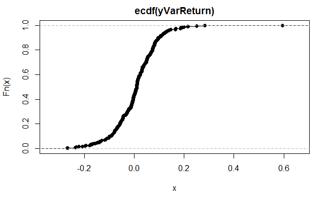

```r
plot(ecdf(yVarReturn))
```

```r
plot(ecdf(yVar))
```

[output not shown]

[output not shown]